# Exercises Day 1 Part 2

Thomas Kuo

2019-09-17

## Loading the dataset

You use the `##` to create a header. Use the header to indicate the question you are answering. After the header, in this space here, annotate your answer, telling us what you did.

````r
# Here is where your R code goes. ``` opens the code chunk, followed by {r}. Then ``` closes the chunk. When you 'knit' the file, the codes will evaluate.

gapminder <- read.csv(here::here("data/gapminder5.csv"), stringsAsFactors=FALSE)
````

## If Statement

Use an if() statement to print a suitable message reporting whether there are any records from 2002 in the gapminder dataset. Now do the same for 2012.

Hint: use the any function.

```r
test_year <- 2002
if (any(gapminder$year == test_year)) {
    print(paste0("There is data for ", test_year))
} else {
        print(paste0("There are no records in ",test_year))
}
```

```
## [1] "There is data for 2002"
```

```r
test_year <- 2012
if (any(gapminder$year == test_year)) {
    print(paste0("There is data for ", test_year))
} else {
        print(paste0("There are no records in ",test_year))
}
```

```
## [1] "There are no records in 2012"
```

## Loop and If Statements

Write a script that finds the mean life expectancy by country for countries whose population is below the mean for the dataset

```r
dataset_mean <- mean(gapminder$pop)
for (i in unique(gapminder$country)) {
    temp_cpop <- mean(gapminder$pop[gapminder$country == i]) #country population
    temp_cmLE <- mean(gapminder$lifeExp[gapminder$country == i]) #mean country life expectancy

    if (temp_cpop < dataset_mean) {
        print(paste0("The mean life expectancy for ", i, " is ", temp_cmLE))
    } else {
        print(paste0("The population for ", i, " is higher than the mean population of the data set"))
    }
}
```

```
## [1] "The mean life expectancy for Afghanistan is 37.4788333333333"
## [1] "The mean life expectancy for Albania is 68.4329166666667"
## [1] "The mean life expectancy for Algeria is 59.0301666666667"
## [1] "The mean life expectancy for Angola is 37.8835"
## [1] "The mean life expectancy for Argentina is 69.0604166666667"
## [1] "The mean life expectancy for Australia is 74.6629166666667"
## [1] "The mean life expectancy for Austria is 73.10325"
## [1] "The mean life expectancy for Bahrain is 65.6056666666667"
## [1] "The population for Bangladesh is higher than the mean population of the data set"
## [1] "The mean life expectancy for Belgium is 73.64175"
## [1] "The mean life expectancy for Benin is 48.7799166666667"
## [1] "The mean life expectancy for Bolivia is 52.5045833333333"
## [1] "The mean life expectancy for Bosnia and Herzegovina is 67.7078333333333"
## [1] "The mean life expectancy for Botswana is 54.5975"
## [1] "The population for Brazil is higher than the mean population of the data set"
```

[output cut: 127 more lines]

Write a script that loops through the gapminder data by continent and prints out whether the mean life expectancy is smaller than 50, between 50 and 70, or greater than 70.

```r
for (i in unique(gapminder$continent)){
    temp_cmLE <- mean(gapminder$lifeExp[gapminder$continent == i]) #mean continent life expectancy

    if (temp_cmLE < 50) {
        print(paste0("The mean life expectancy for ", i, " is ", round(temp_cmLE), " and is less than 50"))
    } else {
        if (temp_cmLE > 70) {
        print(paste0("The mean life expectancy for ", i, " is ", round(temp_cmLE), " and is greater than 70"))
    } else {
        print(paste0("The mean life expectancy for ", i, " is ", round(temp_cmLE), " and is between 50 & 70"))
    }
    }
}
```

```
## [1] "The mean life expectancy for Asia is 60 and is between 50 & 70"
## [1] "The mean life expectancy for Europe is 72 and is greater than 70"
## [1] "The mean life expectancy for Africa is 49 and is less than 50"
## [1] "The mean life expectancy for Americas is 65 and is between 50 & 70"
## [1] "The mean life expectancy for Oceania is 74 and is greater than 70"
```

## Exercise: Writing Functions

Create a function that given a data frame will print the name of each column and the class of data it contains. Use the gapminder dataset. Hint: Use mode() or class() to get the class of the data in each column. Remember that names() or colnames() returns the name of the columns in a dataset.

```r
print_col_and_class <-
    function(dataframe) {
        my_names <- names(dataframe)
        my_class <- lapply(dataframe, class)

        ##length gets the numeric length of my_names
        ##seq turns that length into a sequence to iterate that many times
        for (i in seq(length(my_names))) {
        print(paste0("Column: ", my_names[i], " || Data Class: ", my_class[i]))
        }
    }

print_col_and_class(gapminder)
```

```
## [1] "Column: country || Data Class: character"
## [1] "Column: year || Data Class: integer"
## [1] "Column: pop || Data Class: numeric"
## [1] "Column: continent || Data Class: character"
## [1] "Column: lifeExp || Data Class: numeric"
## [1] "Column: gdpPercap || Data Class: numeric"
```

Create a function that given a vector will print the mean and the standard deviation of a vector, it will optionally also print the median. Hint: include an argument that takes a boolean (TRUE/FALSE) operator and then include an if statement.

```r
print_sd_med <-
    function(vector, boolean = FALSE) {
        fx_mean <- mean(vector)
        fx_sd <- sd(vector)

        #use cat when you have newline character, new line does not work with print
        cat(paste0("Mean: ", fx_mean, "\nStandard Deviation: ", fx_sd))
        if (boolean == TRUE) {
            cat(paste0("\nMedian: ", median(vector),"\n"))
        }
 }

print_sd_med(gapminder$lifeExp, TRUE)
```

```
## Mean: 59.4744393661972
## Standard Deviation: 12.9171074152412
## Median: 60.7125
```

```r
print_sd_med(gapminder$lifeExp,)
```

```
## Mean: 59.4744393661972
## Standard Deviation: 12.9171074152412
```

## Analyzing the Relationship

1/ What is the relationship between GDP per capita and life expectancy? Does this relationship change over time? (Hint: Use the natural log of both variables.)

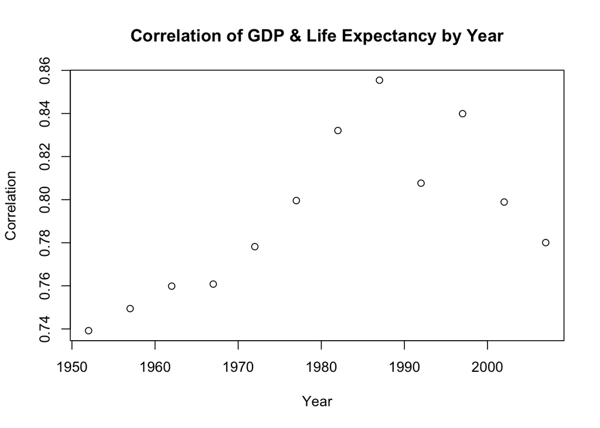

```r
gapminder$log_gdp <- log(gapminder$gdpPercap)
gapminder$log_le <- log(gapminder$lifeExp)

years <- unique(gapminder$year)
corr_vec <- NULL
    for (i in years) {
        year_corr <- cor(gapminder$log_gdp[gapminder$year == i],gapminder$log_le[gapminder$year == i])
        corr_vec <- c(corr_vec, year_corr)
    }

plot(corr_vec ~ years, main = "Correlation of GDP & Life Expectancy by Year", xlab = "Year", ylab = "Correlation")
```

2/ Does the relationship between GDP per capita and life expectacy vary by continent? Make sure you divide the Americas into North and South America.

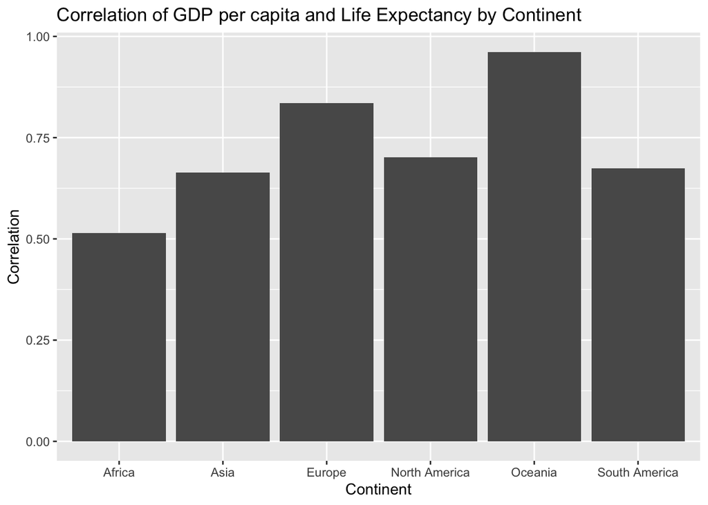

```r
##Split Americas into North and South
gapminder$cont_affinitized <- gapminder$continent
gapminder$cont_affinitized[gapminder$cont_affinitized == "Americas"] <- NA
gapminder$cont_affinitized[gapminder$country == "Canada"] <- "North America"
gapminder$cont_affinitized[gapminder$country == "Guatemala"] <- "North America"
gapminder$cont_affinitized[gapminder$country == "Costa Rica"] <- "North America"
gapminder$cont_affinitized[gapminder$country == "Cuba"] <- "North America"
gapminder$cont_affinitized[gapminder$country == "Dominican Republic"] <- "North America"
gapminder$cont_affinitized[gapminder$country == "El Salvador"] <- "North America"
gapminder$cont_affinitized[gapminder$country == "Haiti"] <- "North America"
gapminder$cont_affinitized[gapminder$country == "Honduras"] <- "North America"
gapminder$cont_affinitized[gapminder$country == "Jamaica"] <- "North America"
gapminder$cont_affinitized[gapminder$country == "Nicaragua"] <- "North America"
gapminder$cont_affinitized[gapminder$country == "Panama"] <- "North America"
gapminder$cont_affinitized[gapminder$country == "Trinidad and Tobago"] <- "North America"
gapminder$cont_affinitized[gapminder$country == "United States"] <- "North America"
gapminder$cont_affinitized[is.na(gapminder$cont_affinitized)] <- "South America"

##evaluate relationship between GDP and life expectancy
gapminder$log_gdp <- log(gapminder$gdpPercap)
gapminder$log_le <- log(gapminder$lifeExp)

continents <- unique(gapminder$cont_affinitized)
corr_vec <- NULL
    for (i in continents) {
        cont_corr <- cor(gapminder$log_gdp[gapminder$cont_affinitized == i],gapminder$log_le[gapminder$cont_affinitized == i])
        corr_vec <- c(corr_vec, cont_corr)
    }
my_df <- data.frame(continents, corr_vec)
library(ggplot2)
ggplot(data = my_df, aes(x = continents, y = corr_vec)) + geom_bar(stat="identity") + ggtitle("Correlation of GDP per capita and Life Expectancy by Continent") + labs(x = "Continent", y = "Correlation")
```